# Retail Analytics Case Study

- Show All Code
- Hide All Code

Uncovering Store Profitability and Geographic Trends

Author

Felix Jena

### Libraries Used Datasets and Tasks

```r
pacman:: p_load(readr, readxl, ggplot2, dplyr, tidyverse, leaflet, pander, DT, leaflet.extras, scales)

file_path <- "Maverik_Interview_Challenge_Data.xlsx"

# Sheet 1 data
store_location <- read_excel(file_path, sheet = 1)
# Sheet 2 data
metrics_data <- read_excel(file_path, sheet = 2)
```

This project was completed as part of a take-home case study for a data analyst interview at a regional convenience retail brand. The goal was to explore store-level performance and geospatial patterns using sample data provided in the assessment.

Note: This work is based on publicly shareable data provided for evaluation purposes only. All insights and interpretations are my own, and no proprietary or confidential information is included in this project. Company names and specific identifiers have been omitted to respect privacy.

## Challenge

Performance Analysis: Calculate the combined gross profit store average for each state, including actionable insights or observations.  
Visualization: Create an insightful map visualization comparing store attributes (from store location data) and financial metrics (from metrics) of your choice.

### Pump Up the Data: Validation Pit Stop

```r
# Pivot Wider
metric <- metrics_data %>%
  pivot_wider(
    names_from = Metric,
    values_from = Value
  )

pander(head(metrics_data))
```

| StoreNumber | Metric | Value |
| --- | --- | --- |
| 130 | FuelGrossProfit | 188275 |
| 130 | InStoreGrossProfit | 194941 |
| 136 | FuelGrossProfit | 290636 |
| 136 | InStoreGrossProfit | 234793 |
| 156 | FuelGrossProfit | 201057 |
| 156 | InStoreGrossProfit | 200821 |

```r
pander(head(metric))
```

| StoreNumber | FuelGrossProfit | InStoreGrossProfit |
| --- | --- | --- |
| 130 | 188275 | 194941 |
| 136 | 290636 | 234793 |
| 156 | 201057 | 200821 |
| 162 | 254720 | 146856 |
| 166 | 275758 | 199879 |
| 168 | 345998 | 227923 |

```r
missing_values_store_location <- store_location[!complete.cases(store_location), ]
missing_values_metrics <- metric[!complete.cases(metric), ]

pander(missing_values_store_location,
  caption = "Missing Values in Store Location Data")
```

Missing Values in Store Location Data (continued below)

| Store Number | Pump Count | Parking Spots | Street |
| --- | --- | --- | --- |
| 537 | NA | 28 | 1290 S. Wallace Rd. |
| 603 | 6 | NA | 303 S Main Street |

| City | State | Zip | Latitude | Longitude |
| --- | --- | --- | --- | --- |
| Salt Lake City | UT | 84104 | 40.74 | -111.9 |
| Logan | UT | 84321 | 41.73 | -111.8 |

```r
pander(missing_values_metrics,
  caption = "Missing Values in Metrics Data")
```

Missing Values in Metrics Data

| StoreNumber | FuelGrossProfit | InStoreGrossProfit |
| --- | --- | --- |
| 623 | NA | 333345 |

**Analysis**:

- Missing values in `Pump Count` for store 537 and `Parking Spots` for store 603 indicate incomplete data for these locations.
- Store 623 lacks `FuelGrossProfit`, which could skew profit-based analyses.
- Further analysis noted that Store 254 had the wrong coordinates (need to refer back to source - Long. & Lat. probably swapped around).

**Workflow**:

1. Used `complete.cases()` to identify rows with missing data.
2. Made use of `pivot_wider`to transform rows into columns.
3. Segregated missing data into separate tables for analysis and review.

**Assumptions**:

- Missing values might indicate errors during data collection or unrecorded attributes for new stores.
- Stores with incomplete data were excluded from further analysis to maintain accuracy.

**Challenges**:

- Deciding whether to exclude or impute missing values for incomplete rows.

### State by State Gross Profit Trail

```r
# Joining Datasets
Store_Metrics <- store_location %>%
  inner_join(metric, by = c("Store Number" = "StoreNumber")) %>%
  filter(!`Store Number` %in% c(254, 537, 603, 623))%>%
  mutate(TotalGrossProfit = FuelGrossProfit + InStoreGrossProfit)

state_avg_gross_profit <- Store_Metrics %>%
  group_by(State) %>%
  summarize(
    "Fuel Gross Profit" = paste0("$ ",round(mean(FuelGrossProfit, na.rm = TRUE),2)),
    "InStore Gross Profit" = paste0("$ ",round(mean(InStoreGrossProfit, na.rm = TRUE),2)),
    "Total Gross Profit" = paste0("$ ",round(mean(FuelGrossProfit + InStoreGrossProfit, na.rm = TRUE),2))
  ) %>%
  arrange(desc("Total Gross Profit"))

datatable(state_avg_gross_profit,
                 options = list(pageLength = 7),
                 caption = "Average Gross Profits by State")
```

|  | State | Fuel Gross Profit | InStore Gross Profit | Total Gross Profit |
| --- | --- | --- | --- | --- |
| 1 | AZ | $ 309983.32 | $ 417856.09 | $ 727839.41 |
| 2 | CA | $ 558590 | $ 636592 | $ 1195182 |
| 3 | CO | $ 393566.88 | $ 489636.12 | $ 883203 |
| 4 | ID | $ 328581.03 | $ 396658.63 | $ 725239.66 |
| 5 | NE | $ 348075.33 | $ 446370 | $ 794445.33 |
| 6 | NM | $ 464866.31 | $ 621689.38 | $ 1086555.69 |
| 7 | NV | $ 396072.62 | $ 506404.69 | $ 902477.31 |
| 8 | OR | $ 390046 | $ 478523 | $ 868569 |
| 9 | SD | $ 441695 | $ 286253.5 | $ 727948.5 |
| 10 | UT | $ 342060.71 | $ 422612.09 | $ 764672.8 |

[output cut: 3 more lines]

**Analysis**:

**Workflow**:

1. Filtered out invalid store data (e.g., missing values).
2. Aggregated gross profits at the state level using `group_by()` and `summarize()`.
3. Displayed the result in an interactive table using `datatable()`.

**Assumptions**:

- Data is accurate and consistently aggregated across states.
- Average gross profit provides meaningful insights for comparing state-level performance.

**Challenges**:

- Handling states with fewer stores, which might skew average values.

### Site Attributes - Geospatial Distribution of Stores

```r
Map_visuals <- Store_Metrics %>%
  mutate(
    popup_info = paste0(
      "<b>Store Number:</b> ", `Store Number`, "<br>",
      "<b>State:</b> ", State, "<br>",
      "<b>Fuel Gross Profit:</b> $", FuelGrossProfit, "<br>",
      "<b>In-Store Gross Profit:</b> $", InStoreGrossProfit, "<br>",
      "<b>Parking Spots:</b> ", `Parking Spots`, "<br>",
      "<b>Pump Count:</b> ", `Pump Count`
    )
  )

leaflet(data = Map_visuals) %>%
  addTiles() %>%
  addCircleMarkers(
    lng = ~Longitude,
    lat = ~Latitude,
    radius = ~TotalGrossProfit / 30000,
    color = "red",
    popup = ~popup_info
  ) %>%
  addLegend(
    position = "bottomright",
    title = "Gross Profit",
    colors = "red",
    labels = "Total Gross Profit"
  )
```

[interactive chart not shown]

**Analysis**:

- High gross-profit-generating stores are concentrated in urban centers or regions with high traffic flow (e.g., Salt Lake City, UT).
- Geographic clustering of high-performing stores reveals strong regional opportunities.
- Larger marker sizes correlate with infrastructure scale and operational success.

**Workflow**:

1. Used `leaflet` to create an interactive map with geospatial data.
2. Added circle markers with popups displaying detailed store metrics.

**Assumptions**:

**Challenges**:

- Balancing marker size for clarity while ensuring interactivity.

### Stats for Nerds: “Fueling” Insights, One Number at a Time

How do parking spots and pump counts influence the total gross profit of our stores?

```r
# Building linear model
profit_model <- lm(TotalGrossProfit ~ `Parking Spots` + `Pump Count`, data = Map_visuals)

pander(summary(profit_model))
```

|  | Estimate | Std. Error | t value | Pr(>\|t\|) |
| --- | --- | --- | --- | --- |
| **(Intercept)** | 169597 | 19587 | 8.659 | 1.508e-16 |
| **`Parking Spots`** | 16707 | 822 | 20.32 | 3.673e-62 |
| **`Pump Count`** | 12480 | 1178 | 10.6 | 4.416e-23 |

Fitting linear model: TotalGrossProfit ~ `Parking Spots` + `Pump Count`

| Observations | Residual Std. Error | $R^2$ | Adjusted $R^2$ |
| --- | --- | --- | --- |
| 372 | 140708 | 0.7573 | 0.756 |

**Analysis**:

- Intercept: When both parking spots and pump counts are zero, the base gross profit is approximately $169,597.
- Parking Spots Coefficient: Each additional parking spot increases total gross profit by $16,707.
- Pump Count Coefficient: Each additional pump adds around $12,480 to the total gross profit.
- High t-values and low p-values confirm the predictors’ statistical significance.

```r
model_residuals <- residuals(profit_model)

pander(summary(model_residuals))
```

| Min. | 1st Qu. | Median | Mean | 3rd Qu. | Max. |
| --- | --- | --- | --- | --- | --- |
| -415609 | -78556 | -7898 | 2.802e-12 | 87945 | 424133 |

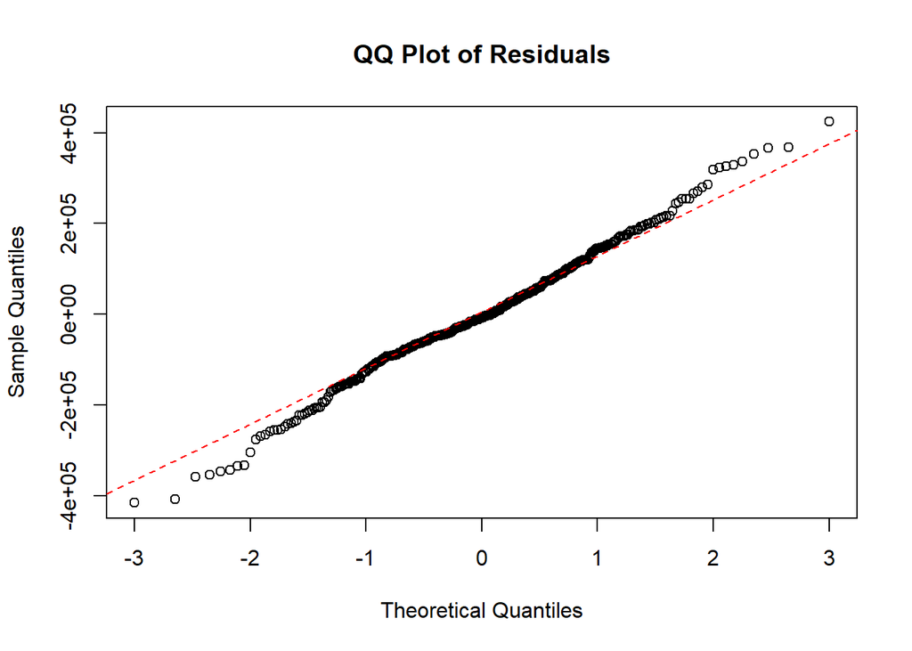

```r
qqnorm(model_residuals, main = "QQ Plot of Residuals")
qqline(model_residuals, col = "red", lty = 2)
```

**Analysis**:

- Optimizing infrastructure (e.g., adding pumps or parking spots) can directly enhance profitability.
- The residuals generally follow a normal distribution, as indicated by their alignment with the theoretical quantile line in the QQ plot.
- Some residuals deviate at the tails, suggesting potential outliers or non-linearities in the data.

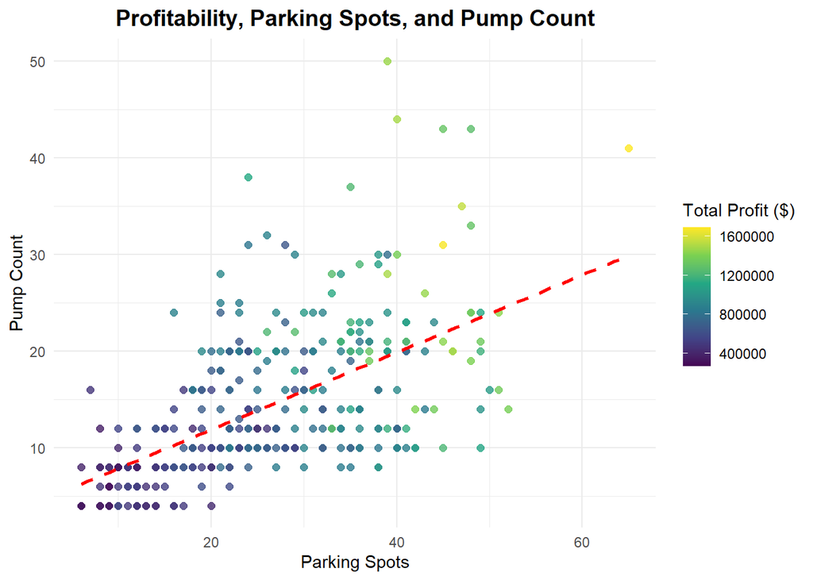

```r
ggplot(Map_visuals, aes(x = `Parking Spots`, y = `Pump Count`)) +
  geom_point(aes(color = FuelGrossProfit + InStoreGrossProfit), size = 2, alpha = 0.8) +
  scale_color_viridis_c(option = "viridis", name = "Total Profit ($)") +
  geom_smooth(method = "lm", se = FALSE, color = "red", linetype = "dashed") +
  labs(
    title = "Profitability, Parking Spots, and Pump Count",
    x = "Parking Spots",
    y = "Pump Count"
  ) +
  theme_minimal() +
  theme(
    plot.title = element_text(hjust = 0.5, size = 14, face = "bold"),
    legend.position = "right"
  )
```

**Analysis**:

**Workflow**:

1. Merged store and metrics datasets.
2. Created a Linear model *aka stats for nerds* using `lm()`.
3. Utilized `qqnorm` to Validate Model Assumptions.
4. Plotted relationships using `ggplot2` with `geom_point()` and `geom_smooth()` for the regression line.

**Assumptions**:

- Positive correlation suggests more infrastructure (pumps and parking spots) leads to higher profitability.

**Challenges**:

- Outliers could impact the regression line’s accuracy.

### Charting the Course: Recommendations

**Supporting Recommendations (Medium Priority)**

4. *Leverage Geospatial Insights:* Use map visualizations to identify trends and replicate successful store designs.
5. *Targeted Marketing Campaigns:* Focus on stores with high potential but underwhelming performance to maximize revenue.
6. *Investigate Store-Level Performance:* Understand outliers where similar infrastructure yields different results (qualitative research).

**Long-Term Recommendations (Low Priority or Strategic)**

7. *Predictive Modeling:* Use regression models to guide new store openings or expansions.
8. *Sustainability Initiatives:* Explore adding eco-friendly features to align with customer trends and future-proof operations.